# Lab 4

Marissa Zuyus

9/18/2020

# Task 1

Get wd

```r
getwd()
```

```
## [1] "/Users/marissazuyus/Desktop/Stat/Lab 4"
```

# Task 2

```r
spruce.df = read.csv("SPRUCE.csv")
tail(spruce.df)
```

```
##    BHDiameter Height
## 31       17.7   19.9
## 32       20.7   19.4
## 33       21.0   20.4
## 34       13.3   15.5
## 35       15.9   17.6
## 36       22.9   19.2
```

# Task 3

## Lowess smoother scatter slot

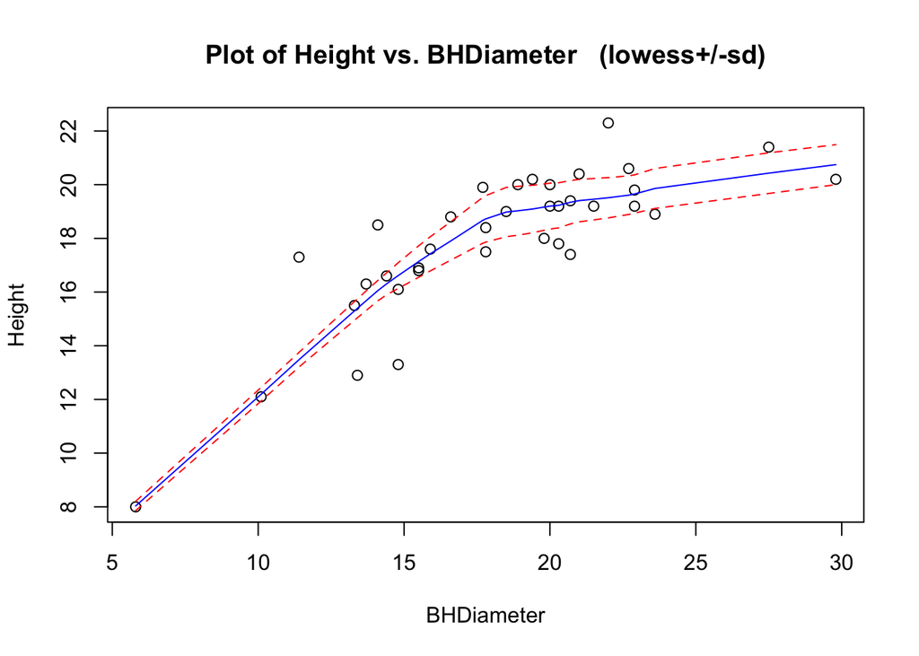

```r
library(s20x)
trendscatter(Height~BHDiameter, data=spruce.df, f = 0.5)
```

## Make a linear model object

```r
spruce.lm = with(spruce.df, lm(Height~BHDiameter))
```

## Find residuals

```r
height.res = residuals(spruce.lm)
```

## Find fitted values

```r
height.fit = fitted(spruce.lm)
```

## Residuals vs fitted

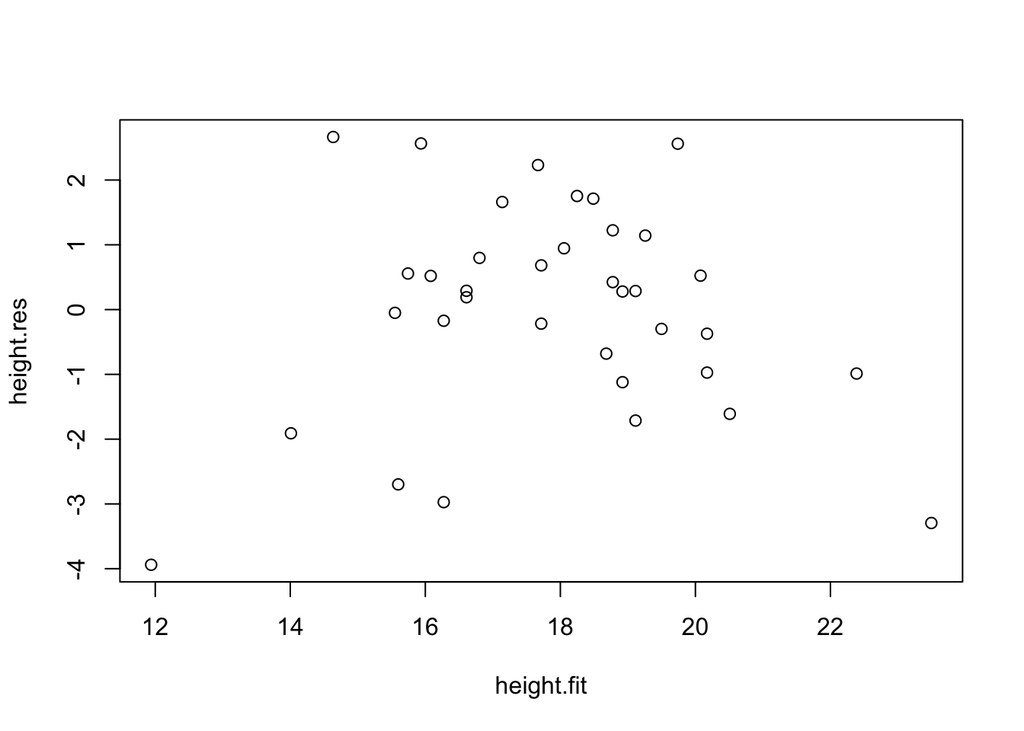

```r
plot(y=height.res, x=height.fit)
```

## Residuals vs fitted used trendscatter

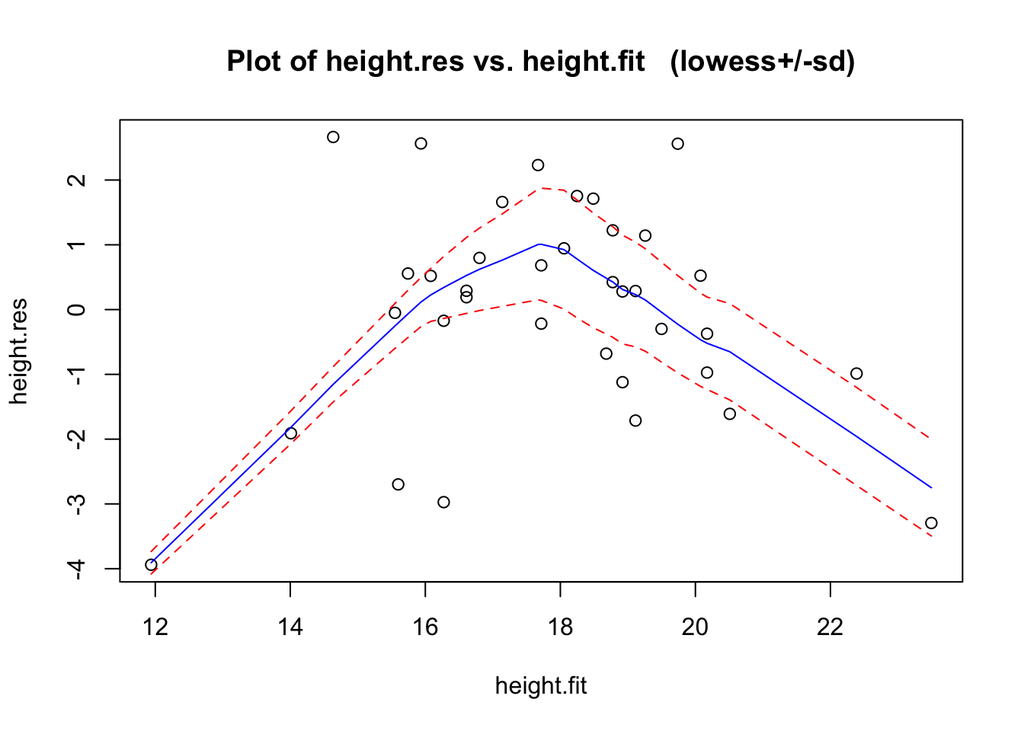

```r
trendscatter(y=height.res, x = height.fit)
```

## Shape of the plot

The plot is symmetrical and is a parabolic shape. In this plot, instead of going flat after the peak, the slope of the blue line starts to drop. The difference is because of the x and y data, suggesting that a linear model is not appropriate for this data and something like a quadratic would fit better.

## Residual plot

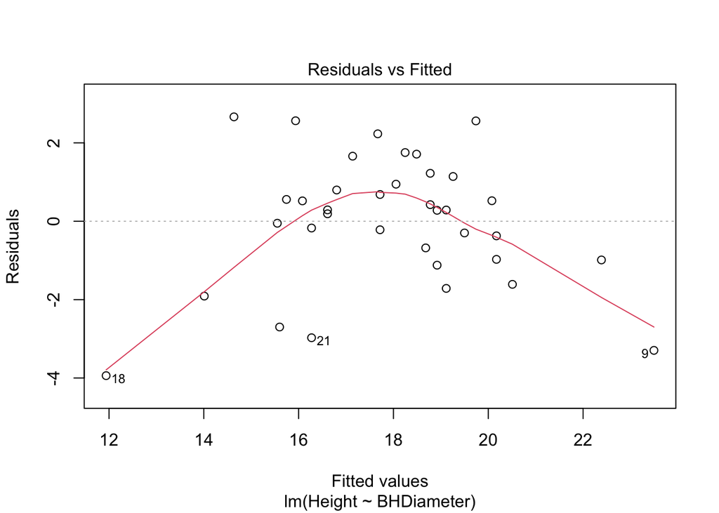

```r
plot(spruce.lm, which=1)
```

## Check normality

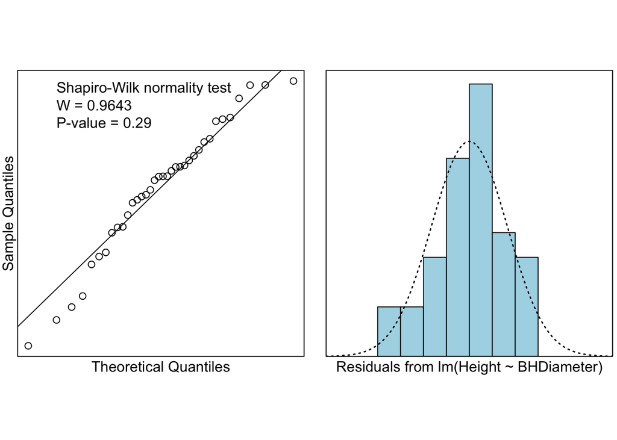

```r
normcheck(spruce.lm, shapiro.wilk=TRUE)
```

## P-value and null-hypothesis

The p-value is .29, and because this is greater than .05 we accept the null hypothesis which says our error is distributed normally. According to the Lab 4 write up, if the model works well with the data we should expect that the residuals are approximately normal in distribution with mean 0 and constant variance.

## Evaluating the model

```r
round(mean(height.res), 4)
```

```
## [1] 0
```

The mean is 0 for the residuals.

## Conclusion

We should not use a straight line model, as shown by the shape of the plot of residuals vs fitted height values. Because this model does not fit the data, we must adjust to a model better suited to fit a quadratic shape.

# Task 4

## Fit a quadratic

```r
quad.lm = lm(Height~BHDiameter + I(BHDiameter^2),data=spruce.df)
summary(quad.lm)
```

```
##
## Call:
## lm(formula = Height ~ BHDiameter + I(BHDiameter^2), data = spruce.df)
##
## Residuals:
##     Min      1Q  Median      3Q     Max
## -3.2966 -0.6245 -0.0707  0.7442  3.2541
##
## Coefficients:
##                  Estimate Std. Error t value Pr(>|t|)
## (Intercept)      0.860896   2.205022   0.390 0.698731
## BHDiameter       1.469592   0.243786   6.028 8.88e-07 ***
## I(BHDiameter^2) -0.027457   0.006635  -4.138 0.000227 ***
## ---
## Signif. codes:  0 '***' 0.001 '**' 0.01 '*' 0.05 '.' 0.1 ' ' 1
##
## Residual standard error: 1.382 on 33 degrees of freedom
## Multiple R-squared:  0.7741, Adjusted R-squared:  0.7604
## F-statistic: 56.55 on 2 and 33 DF,  p-value: 2.182e-11
```

## Make fresh plot and add quadratic curve

```r
coef(quad.lm)
```

```
##     (Intercept)      BHDiameter I(BHDiameter^2)
##      0.86089580      1.46959217     -0.02745726
```

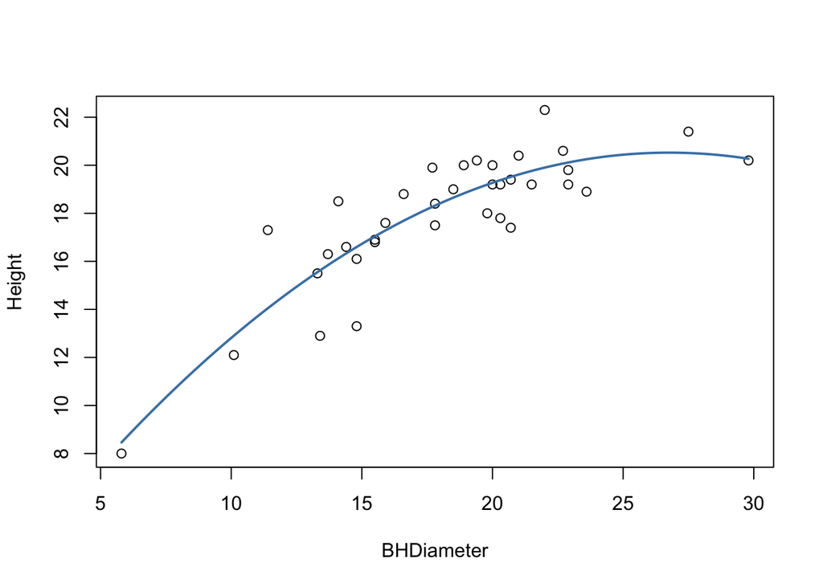

```r
plot(spruce.df)

myplot=function(x){
 0.86089580 +1.46959217*x  -0.02745726*x^2
}

curve(myplot, lwd=2, col="steelblue",add=TRUE)
```

## Make quad.fit

```r
quad.fit = fitted(quad.lm)
```

## Residuals vs fitted

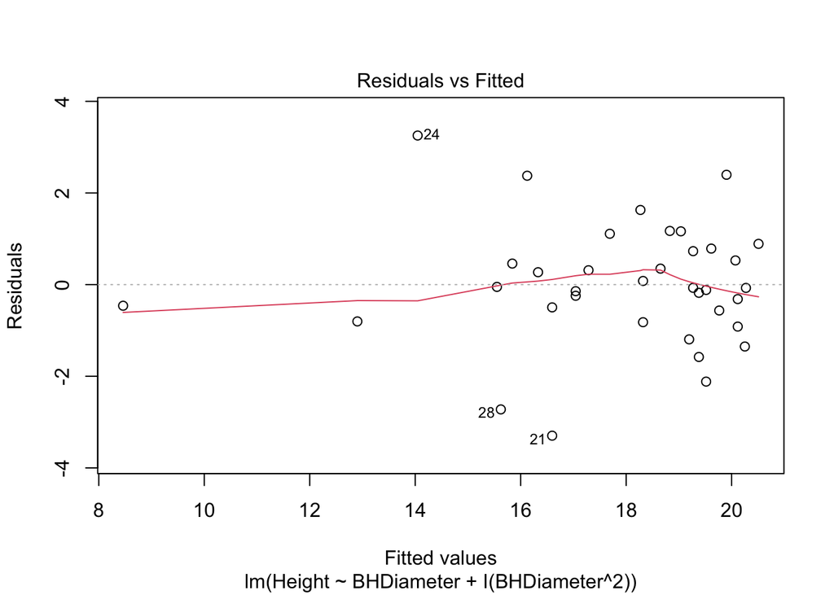

```r
plot(quad.lm,which=1)
```

## Check normality

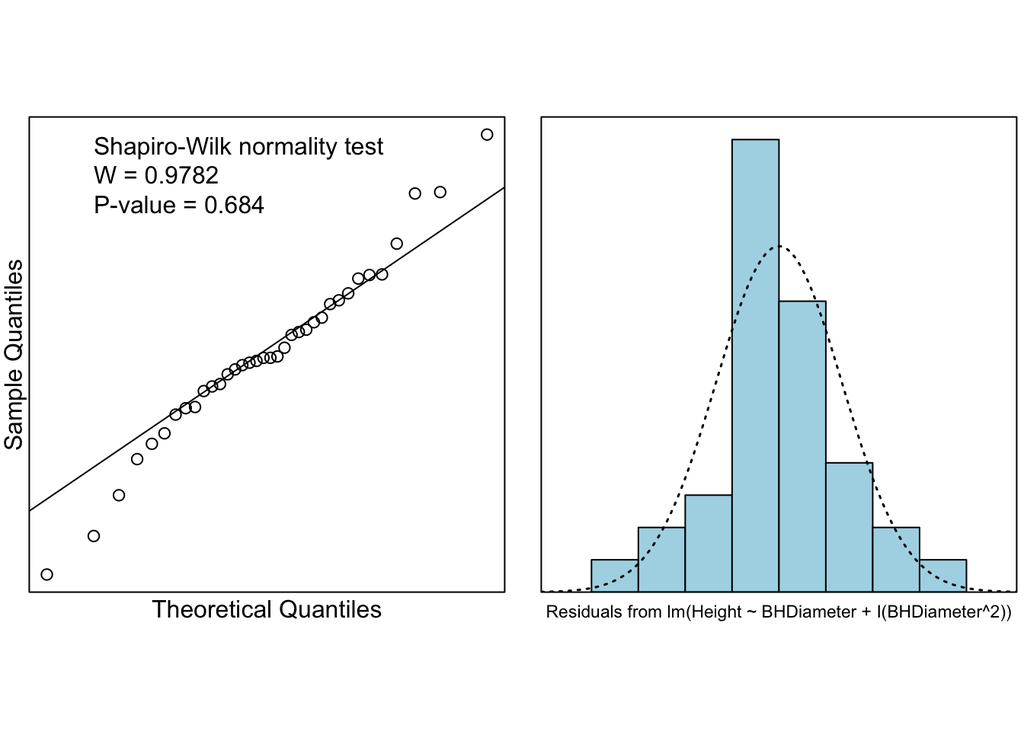

```r
normcheck(quad.lm, shapiro.wilk=TRUE)
```

## Conclusion

The p-value is .684 which is even better than before, so we accept the null hypothesis. This quadratic model fits the plot of the data better than the linear model.

# Task 5

## Summarize quad.lm

```r
summary(quad.lm)
```

```
##
## Call:
## lm(formula = Height ~ BHDiameter + I(BHDiameter^2), data = spruce.df)
##
## Residuals:
##     Min      1Q  Median      3Q     Max
## -3.2966 -0.6245 -0.0707  0.7442  3.2541
##
## Coefficients:
##                  Estimate Std. Error t value Pr(>|t|)
## (Intercept)      0.860896   2.205022   0.390 0.698731
## BHDiameter       1.469592   0.243786   6.028 8.88e-07 ***
## I(BHDiameter^2) -0.027457   0.006635  -4.138 0.000227 ***
## ---
## Signif. codes:  0 '***' 0.001 '**' 0.01 '*' 0.05 '.' 0.1 ' ' 1
##
## Residual standard error: 1.382 on 33 degrees of freedom
## Multiple R-squared:  0.7741, Adjusted R-squared:  0.7604
## F-statistic: 56.55 on 2 and 33 DF,  p-value: 2.182e-11
```

## Beta hat values

$\hat{\beta_{0}}$ = 0.860896

$\hat{\beta_{1}}$ = 1.469592

$\hat{\beta_{2}}$ = -0.027457

## Interval estimates

```r
ciReg(quad.lm)
```

```
##                 95 % C.I.lower    95 % C.I.upper
## (Intercept)           -3.62525           5.34705
## BHDiameter             0.97361           1.96558
## I(BHDiameter^2)       -0.04096          -0.01396
```

## Equation of fitted line

$\hat{Height} = 0.860896 + 1.469592x - 0.027457x^2$

## Height predictions

```r
predict(quad.lm, data.frame(BHDiameter = c(15,18,20)))
```

```
##        1        2        3
## 16.72690 18.41740 19.26984
```

## Comparison

```r
predict(spruce.lm, data.frame(BHDiameter = c(15,18,20)))
```

```
##        1        2        3
## 16.36895 17.81338 18.77632
```

The predictions made by quad.lm follow quadratic growth and are larger than the spruce.lm predictions.

## Multiple r-squared

### quad.lm

```r
summary(quad.lm)$r.squared
```

```
## [1] 0.7741266
```

$R^2 = 0.7741266$

### spruce.lm

```r
summary(spruce.lm)$r.squared
```

```
## [1] 0.6569146
```

$R^2 = 0.6569146$

## Adjusted r-squared

```r
summary(quad.lm)$adj.r.squared
```

```
## [1] 0.7604373
```

```r
summary(spruce.lm)$adj.r.squared
```

```
## [1] 0.6468239
```

The adjusted r-squared shows how well data fits a model. If more variables are added and the data improves, r-squared goes up, whereas if the addition of the added variables makes the model weaker, the r-squared decreases.Based on the adjusted r-squared values of quad.lm and spruce.lm, quad.lm is a better fit (higher r-squared value).

## Meaning of multiple r-squared

It means how well the model itself describes the data and is not dependent on the number nor the effectiveness of included variables. The multiple r-squared value basically describes how quad.lm and spruce.lm are as models.

## Model with most variability

```r
summary(quad.lm)$r.squared
```

```
## [1] 0.7741266
```

```r
summary(quad.lm)$adj.r.squared
```

```
## [1] 0.7604373
```

```r
summary(spruce.lm)$r.squared
```

```
## [1] 0.6569146
```

```r
summary(spruce.lm)$adj.r.squared
```

```
## [1] 0.6468239
```

Both the r-squared and adjusted r-squared values of quad.lm are greater than those of spruce.lm, so quad.lm explains the most variability in height.

## anova

```r
anova(spruce.lm)
```

```
## Analysis of Variance Table
##
## Response: Height
##            Df  Sum Sq Mean Sq F value    Pr(>F)
## BHDiameter  1 183.245 183.245  65.101 2.089e-09 ***
## Residuals  34  95.703   2.815
## ---
## Signif. codes:  0 '***' 0.001 '**' 0.01 '*' 0.05 '.' 0.1 ' ' 1
```

```r
anova(quad.lm)
```

```
## Analysis of Variance Table
##
## Response: Height
##                 Df  Sum Sq Mean Sq F value    Pr(>F)
## BHDiameter       1 183.245 183.245  95.975 2.701e-11 ***
## I(BHDiameter^2)  1  32.696  32.696  17.125 0.0002269 ***
## Residuals       33  63.007   1.909
## ---
## Signif. codes:  0 '***' 0.001 '**' 0.01 '*' 0.05 '.' 0.1 ' ' 1
```

```r
anova(spruce.lm, quad.lm)
```

```
## Analysis of Variance Table
##
## Model 1: Height ~ BHDiameter
## Model 2: Height ~ BHDiameter + I(BHDiameter^2)
##   Res.Df    RSS Df Sum of Sq      F    Pr(>F)
## 1     34 95.703
## 2     33 63.007  1    32.696 17.125 0.0002269 ***
## ---
## Signif. codes:  0 '***' 0.001 '**' 0.01 '*' 0.05 '.' 0.1 ' ' 1
```

Because of its smaller RSS value, quad.lm fits the data closer than spruce.lm.

## TSS, MSS, RSS

```r
height.qfit=fitted(quad.lm)
```

### TSS

```r
TSS = with(spruce.df, sum((Height - mean(Height))^2))
TSS
```

```
## [1] 278.9475
```

### MSS

```r
MSS = with(spruce.df, sum((height.qfit-mean(Height))^2))
MSS
```

```
## [1] 215.9407
```

### RSS

```r
RSS=with(spruce.df, sum((Height-height.qfit)^2))
RSS
```

```
## [1] 63.00683
```

## MSS / TSS

```r
MSS / TSS
```

```
## [1] 0.7741266
```

# Task 6

## Cook’s Plot

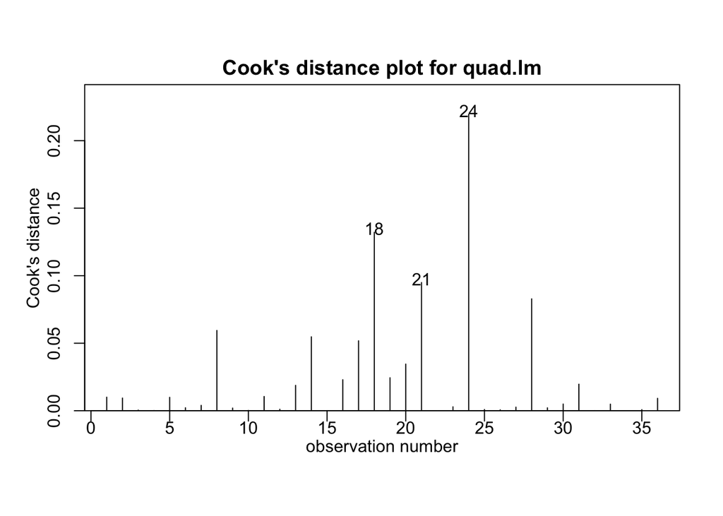

```r
cooks20x(quad.lm, main="Cook's distance plot for quad.lm")
```

## What Cook’s distance is

This is the measure of how much a data point would change the regression analysis if it were deleted. The greater the distance, the greater the impact. Distance is based on the data’s impact on fitted response values. This is used to find outliers and can suggest which datum to remove if a new model is wanted without a large influencer.The model can be improved by removing outlier data that may be distorting it, and this can be observed if the r-squared value increases.

## Cook’s distance for quad.lm

Cook’s distance says that the 24th datum in the data is the most influential as it has the tallest height on the plot.

## quad2.lm

```r
quad2.lm = lm(Height~BHDiameter + I(BHDiameter^2), data = spruce.df[-24,])
```

## quad2.lm summary

```r
summary(quad2.lm)
```

```
##
## Call:
## lm(formula = Height ~ BHDiameter + I(BHDiameter^2), data = spruce.df[-24,
##     ])
##
## Residuals:
##      Min       1Q   Median       3Q      Max
## -3.11233 -0.48227  0.01253  0.71727  2.59146
##
## Coefficients:
##                  Estimate Std. Error t value Pr(>|t|)
## (Intercept)     -0.341500   2.068479  -0.165     0.87
## BHDiameter       1.564793   0.226102   6.921 7.78e-08 ***
## I(BHDiameter^2) -0.029242   0.006114  -4.782 3.74e-05 ***
## ---
## Signif. codes:  0 '***' 0.001 '**' 0.01 '*' 0.05 '.' 0.1 ' ' 1
##
## Residual standard error: 1.266 on 32 degrees of freedom
## Multiple R-squared:  0.8159, Adjusted R-squared:  0.8044
## F-statistic: 70.91 on 2 and 32 DF,  p-value: 1.74e-12
```

## Comparison with quad.lm

```r
summary(quad.lm)
```

```
##
## Call:
## lm(formula = Height ~ BHDiameter + I(BHDiameter^2), data = spruce.df)
##
## Residuals:
##     Min      1Q  Median      3Q     Max
## -3.2966 -0.6245 -0.0707  0.7442  3.2541
##
## Coefficients:
##                  Estimate Std. Error t value Pr(>|t|)
## (Intercept)      0.860896   2.205022   0.390 0.698731
## BHDiameter       1.469592   0.243786   6.028 8.88e-07 ***
## I(BHDiameter^2) -0.027457   0.006635  -4.138 0.000227 ***
## ---
## Signif. codes:  0 '***' 0.001 '**' 0.01 '*' 0.05 '.' 0.1 ' ' 1
##
## Residual standard error: 1.382 on 33 degrees of freedom
## Multiple R-squared:  0.7741, Adjusted R-squared:  0.7604
## F-statistic: 56.55 on 2 and 33 DF,  p-value: 2.182e-11
```

The median, min, and max residuals are smaller for quad2.lm. Both the r-squared and adjusted r-squared values for quad2.lm are larger than quad.lm’s.

## Conclusion

The Cook’s distance plot was correct in indicating the 24th datum was impacting the model because after we removed it, the r-squared values of the data increased.

# Task 7

## Proof

There are two lines with the point $x_{k}$ in common

$l_{1} : y - {\beta_0} + {\beta_1}x$

$l_{2} : y - {\beta_0} + {\delta} + ({\beta_1} + {\beta_2})x$

Next plug in the point $x_{k}$ and set the equations equal to eachother

$y_{k} = {\beta_0} + {\beta_1}x_{k} = {\beta_0} + {\delta} + ({\beta_1} + {\beta_2})x_{k}$

Distribute $x_{k}$ on the right hand side

${\beta_0} + {\beta_1}x_{k} - {\beta_0} + {\delta} + {\beta_1}x_{k} + {\beta_2}x_{k}$

Cancel out ${\beta_0}$ and ${\beta_1}x$

$0={\delta}+{\beta_2}x_{k}$

Substitute ${\delta} = -{\beta_2}x_{k}$ and distribute x

$l_{2}: y={\beta_0} - {\beta_2}x_{k} + {\beta_1}x + {\beta_2}x$

Rearrange and factor out ${\beta_2}$

$l_2: y= {\beta_0} + {\beta_1}x + {\beta_2}(x-x_{k})$

Now that there is a formula that describes $l_{2}$ as an adjustment of $l_{1}$, we can use an indicator function to allow our function to know where it should and should not include the adjustment.

$y={\beta_0} + {\beta_1}x + {\beta_2}(x-x_{k})I(x>x_{k})$

Where I() is 1 if x > $x_{k}$ and 0 else.

## Reproducing the plot

```r
sp2.df = within(spruce.df, X<- (BHDiameter-18) *( BHDiameter> 18))
sp2.df
```

```
##    BHDiameter Height    X
## 1        18.9   20.0  0.9
## 2        16.6   18.8  0.0
## 3        15.5   16.8  0.0
## 4        15.5   16.9  0.0
## 5        19.4   20.2  1.4
## 6        13.7   16.3  0.0
## 7        20.0   20.0  2.0
## 8        27.5   21.4  9.5
## 9        29.8   20.2 11.8
## 10       20.3   19.2  2.3
## 11       19.8   18.0  1.8
## 12       22.9   19.8  4.9
## 13       20.3   17.8  2.3
## 14       14.1   18.5  0.0
```

[output cut: 22 more lines]

```r
lmp = lm(Height~BHDiameter + X, data = sp2.df)
tmp = summary(lmp)
names(tmp)
```

```
##  [1] "call"          "terms"         "residuals"     "coefficients"
##  [5] "aliased"       "sigma"         "df"            "r.squared"
##  [9] "adj.r.squared" "fstatistic"    "cov.unscaled"
```

```r
myf = function(x,coef){
  coef[1]+coef[2]*(x) + coef[3]*(x-18)*(x-18>0)
}
plot(spruce.df, main="Piecewise regression")
myf(0, coef=tmp$coefficients[,"Estimate"])
```

```
## (Intercept)
##    4.499237
```

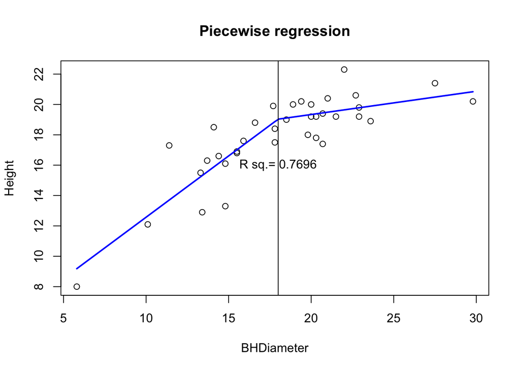

```r
curve(myf(x,coef=tmp$coefficients[,"Estimate"] ),add=TRUE, lwd=2,col="Blue")
abline(v=18)
text(18,16,paste("R sq.=",round(tmp$r.squared,4) ))
```

# Task 8

The function pareto() will take a vector of numbers (and also titles) and will display a pareto chart of the data. This chart includes a barplot of individual values represented in descending order, as well as the cumulative total represented by the line. The data used to represent this function is from Assignment 1.

```r
library(PackageZuyus)

limb.counts = c(15, 8, 63, 20);
limb.labels = c("None", "Both", "Legs ONLY", "Wheels ONLY");
limb.freq.df = as.data.frame(matrix(data= limb.counts/sum(limb.counts), nrow=4, ncol=1), row.names = limb.labels);
limb.freq.df
```

```
##                    V1
## None        0.1415094
## Both        0.0754717
## Legs ONLY   0.5943396
## Wheels ONLY 0.1886792
```

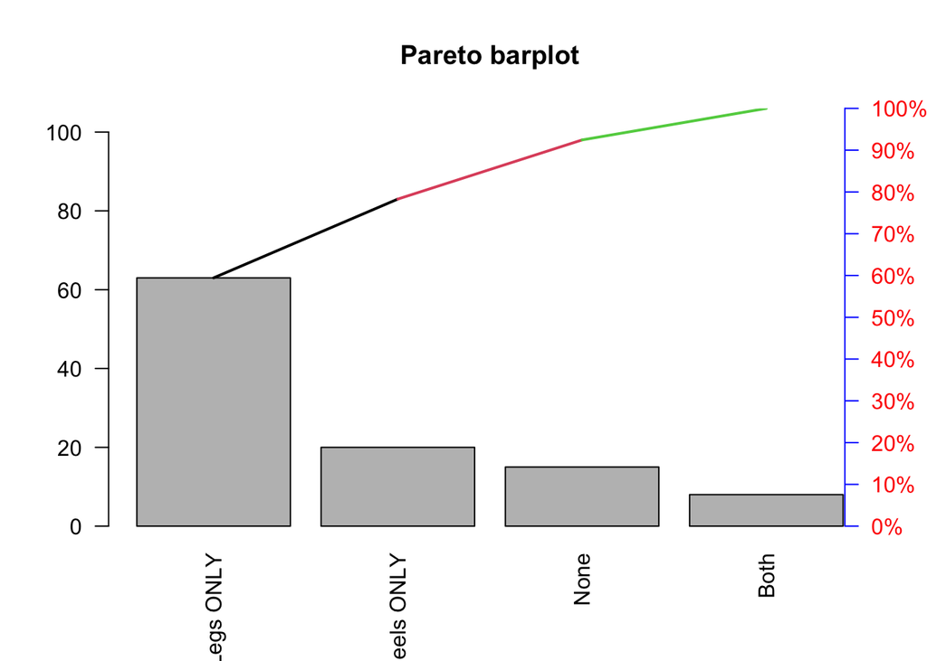

```r
limb.raw = rep(limb.labels, limb.counts);
pareto(limb.raw)
```